# R-Markdown Workshop

Yeamin Faria Chowdhury & Michael Tiefelsdorf

2025-09-15

# 1 Introduction

R Markdown is dynamic authoring tool that allows one to combine in one documents R code, its output and interpretive text. Note: R Markdown also support Quarto, which is more flexible and thus more complex. Overall, the syntax of R Markdown and Quarto is very similar. There are four types of input to be concerned with while working with R markdown,

1. **Metadata**: In the beginning of the document is the YAML header, which is enclosed by `---`. It contains information about the general appearance of the document, e.g., pdf, html or PowerPoint and choice of fonts, table of content etc.
2. **Global** `R` options The global `R` options apply to all code chunks, but they can be overwritten in individual code chucks. See the example below:

```r
##
## Setting global options, which apply to the whole document
##
knitr::opts_chunk$set(
  error = TRUE,         # document will knit even if code chunk contains error
  fig.align = 'center', # center graphs on the page
  out.width = '90%',    # graphs take 90% of available width
  warning = FALSE,      # prevents warnings in the knitted output
  message = FALSE,      # prevents messages in the knitted output
  size = 'small',       # slightly smaller LaTeX output
  tidy = FALSE          # shows code like you wrote it
)
```

3. **Formatted Text**: It contains the explanation on the code, background information, interpretations of results etc. The text can be formatted with fairly straightforward formatting commands.
4. **Code chunks**: They contain the `R` code to be executed which is denoted by `` (```{R}) `` at the beginning of the chunk and `` (```) `` at the end. The output can also be included if needed.

Two brief documents provide an easily accessible introduction to R Markdown:

1. [Chapter 11 Introduction to R Markdown in “Geospatial Health Data: Modeling and Visualization with R-INLA and Shiny”](https://www.paulamoraga.com/book-geospatial/sec-rmarkdown.html)
2. [Chapter 27: R Markdown as well as Chapters 29 and 30 in “R for Data Science”](https://r4ds.had.co.nz/r-markdown.html). The R Markdown version of this book can be found on [github](https://github.com/hadley/r4ds)

# 2 Text Formatting

## 2.1 Headings and Sections

Headings and sections of different levels are created with `#`.

- `#` indicates first level, e.g., chapter title,
- `##` indicates second level, e.g., section title, and so on.

Unordered list is created using `-`, `*` or `+` and one list within another list can be created by indenting the sub-list by four blanks as below:

- Item 1
  - Sub-item 1.1
    - Sub-sub-item 1.1.1
      - Sub-sub-sub-item 1.1.1.1
- Item 2
- Item 3

Ordered list items are created with numbers, e.g.,

1. Item 1
2. Item 2
   - one unordered item

## 2.2 Font styles and effects

- *Italic text*: `*text*` or `_text_`
- **Bold text**: `**text**` or `__text__`
- *Bold italics text*: `***text***` or `___text___`
- `Typewriter (code) text`: `text`
- Endash (`--`), emdash(—): `--` and `---`
- <sup>superscript</sup> and <sub>subscript</sub>: `^superscript^` and `~subscript~`
- strikethrough: `~~strikethrough~~`

## 2.3 Manual line breaks

Multiple sentences can be written by using `\` or by pressing `space key` two times and then hitting `Enter` and then starting the new sentence.

## 2.4 Blockquotes

Blockquotes are written after >, e.g.,  
`> "The way to learn a new programming language is by writing programs in it.">> --- Dennis Ritchie`

And the output looks like this:

> “The way to learn a new programming language is by writing programs in it.”

> — Dennis Ritchie

## 2.5 Adding links

`[wikipedia](http://wikipedia.com)`

The output looks like this. Look it up at [wikipedia](http://wikipedia.com).

## 2.6 Text Color

Text blocks can be set to a different color by changing the style option which is written as:  
`::: {style="color: red;"} Hello **world**! :::`

And the output looks like this:

Hello **world**!

## 2.7 Tables

- One way to print table is to simply run it from the code chunk:

```r
data <- trees[1:4, ]
data
```

```
##   Girth Height Volume
## 1   8.3     70   10.3
## 2   8.6     65   10.3
## 3   8.8     63   10.2
## 4  10.5     72   16.4
```

- Pipe tables with aligned columns are typed using the positioning character `:`:

```
|   Source    |  df  |   Sum of Sq   |    Mean Sq    |    F   |  $Pr(>F_{1,29})$    |
|:------------|-----:|--------------:|--------------:|-------:|:-------------------:|
|  Girth      |  1   |  7581.8       |  7581.8       | 419.26 |  **< 2.2e-16**      |
|  Residual   |  29  |  524.3        |   18.1        |        |                     |
```

| Source | df | Sum of Sq | Mean Sq | F | $Pr(>F_{1,29})$ |
| --- | --- | --- | --- | --- | --- |
| Girth | 1 | 7581.8 | 7581.8 | 419.26 | **< 2.2e-16** |
| Residual | 29 | 524.3 | 18.1 |  |  |

- You can also insert a table by using the ‘knitr::kable( )’:

```r
knitr::kable(iris[1:5, ], caption = 'Table: A caption')
```

Table: A caption

| Sepal.Length | Sepal.Width | Petal.Length | Petal.Width | Species |
| --- | --- | --- | --- | --- |
| 5.1 | 3.5 | 1.4 | 0.2 | setosa |
| 4.9 | 3.0 | 1.4 | 0.2 | setosa |
| 4.7 | 3.2 | 1.3 | 0.2 | setosa |
| 4.6 | 3.1 | 1.5 | 0.2 | setosa |
| 5.0 | 3.6 | 1.4 | 0.2 | setosa |

## 2.8 Inserting images

To insert figures use the syntax `![Fig: R Markdown hex logo](logo.png)`.

The output looks like this:

[figure not shown]

Fig: R Markdown hex logo

To get more control over the attributes of the image, you may use the `knitr::include_graphics()` function:

`{r, out.width='25%', fig.align='center', fig.cap='R Markdown hex logo'} knitr::include_graphics('logo.png')`

And the output looks like this:

[figure not shown]

R Markdown hex logo

```r
knitr::include_graphics('logo.png')
```

# 3 Code Chunks

The code chunk are inserted by using the RStudio toolbar button (the `Insert a new code chunk` button) on the right side or by using the keyboard shortcut Ctrl + Alt + I (Cmd + Option + I on macOS). The R-codes are written and run inside the chunks.

The following plot is generated with the options `` ```{r snippet-plot, echo=TRUE, include=TRUE, fig.height=4, fig.width=4, fig.cap = "The plot for x against x^2"})``` ``

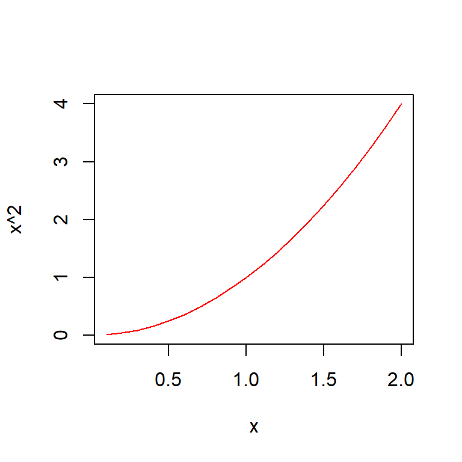

```r
x <- seq(0.1, 2, by=0.1)
plot(x,x^2, type="l", col="red")
```

There is an option to assign a name to a code chunks - `{r chunk-name}`. This is especially useful while troubleshooting an error in the document. A code error could be tracked down by the chunks name. If the label or name of a chunk is missing, a default one of the form `unnamed-chunk-i` will be generated, where `i` is incremental.

There are many chunk options available for customizing the behavior of code chunks in R Markdown documents. The chunk name and the code chunk options are written inside the curly braces and are separated by commas. Almost 60 chunk options are documented in the knitr package [here](https://yihui.org/knitr/options/).

If a certain chunk option needs to be frequently used in multiple code chunks, set them the global code chunk at the beginning of your document.

## 3.1 Some keyboard shortcuts

The following keyboard shortcuts are worthwhile memorizing.

R Markdown keyboard shortcuts

| Task | Windows & Linux | macOS |
| --- | --- | --- |
| Insert R chunk | Ctrl+Alt+I | Command+Option+I |
| Preview HTML | Ctrl+Shift+K | Command+Shift+K |
| Run all chunks above | Ctrl+Alt+P | Command+Option+P |
| Run current chunk | Ctrl+Alt+C | Command+Option+C |
| Run current chunk | Ctrl+Shift+Enter | Command+Shift+Enter |
| Run next chunk | Ctrl+Alt+N | Command+Option+N |

## 3.2 Saving the code chunks only

You can save just the pure `R` code from a R Markdown document residing in the working directory by using the syntax, `knitr::purl("Doc.Rmd", documentation = 0)`

# 4 YAML header

YAML header stands for “yet another markup language’. YAML header contains YAML arguments - ‘title’, ‘author’ and ‘output’, demarcated by three dashes (-) on either end.

- Title: The title in the YAML header - `(title: "My Title")` will appear at the top of the document with font larger than rest of the document.
- Author: Author’s name can be specified which will appear at the head of the document below the title
- Date: Date can be specified at the header which will be added to the head of the document. Date can be set as static or dynamic. Using the `Sys.Date()` function will update the `date` field in the YAML each time the document is knitted.
- Other YAML options:
  - toc: true/false to show table of contents. The headings of the document is directly reached from this link.
  - toc_depth: This determines how many subheadings will be visible in the TOC
  - toc_float: true/false determines whether the TOC stays visible upon scrolling.
  - number_sections: true/false organizes the document with numeric headings
  - code_folding: true/false displays code in collapsible sections. It can be one of “none”, “hide”, “show”.
  - theme: Change the overall look of the report. It can be one of “default”, “cerulean”, “journal”, “flatly”, “darkly”, “readable”, “spacelab”, “united”, “cosmo”, “lumen”, “paper”, “sandstone”, “simplex”, “yeti”.
- References: Files with references can be added by using the keyword statement `bibliography: filename.filetype` in the header. Learn more about creating citations in the .Rmd file [here](https://r4ds.had.co.nz/r-markdown.html#yaml-header).

# 5 Output options

This is the part of the header where you specify the format in which you want to publish your document. Some output format of interest are:

- output: html_document
- output: pdf_document
- output: word_document (.docx)
- interactive shiny apps

# 6 Notebook (HTML Document)

R Notebook is a document type in R markdown which is more interactive, where the code chunks are executed one at a time. Instead of knitting into different formats, the `Preview` option in R notebook allows to view the output document in the viewer pane. Saving a notebook .Rmd creates a .nb.html file along with the .rmd file automatically, which can be viewed in any browser and shared with others.

# 7 Presentations

R markdown can also be used to produce presentations, where the results of the R code are properly formatted and saved into presentation slides. It is very efficient way generating slide shows. Presentations can be obtained by rendering the R markdown file in the PowerPoint format, so that the produced presentation can be further edited in Microsoft PowerPoint. Each slide will begin with a first level (`#`) or second level (`##`) header, or by inserting horizontal rule (`***`) to create a new slide without a header.

# 8 LaTex Output

In R markdown, LaTeX language is used to process equations. Html-documents do not require an extra installation of LaTeX. There are two writing modes for mathematical expression, i.e., [a] inline math mode and [b] display math mode.

## 8.1 Inline Equations:

Inline math equations are put in between single dollar sign. Thus, $\hat{\sigma}^2=\frac{1}{n-1} \cdot \sum_{i=1}^n{(x_i-\bar{x})^2}$ can be written as: `$\hat{\sigma}^2=\frac{1}{n-1} \cdot \sum_{i=1}^n{(x_i-\bar{x})^2}$`.

## 8.2 Display Equations:

In order to write equations in Display mode, we start with two dollar signs (`$$`) at either ends. Anything between these signs will be processed as equations. Such as,
$$\hat{\sigma}^2=\frac{1}{n-1} \cdot \sum_{i=1}^n{(x_i-\bar{x})^2}$$
is written as: `$$ \hat{\sigma}^2=\frac{1}{n-1} \cdot \sum_{i=1}^n{(x_i-\bar{x})^2} $$`

# 9 Some cheatsheets

1. [evoldyn.gitlab.io](https://evoldyn.gitlab.io/evomics-2018/ref-sheets/rmarkdown-2.0_layout2.pdf)
2. [www.rstudio.com](https://www.rstudio.com/wp-content/uploads/2015/02/rmarkdown-cheatsheet.pdf)

# 10 Web-Reference links

1. [R Markdown: The Definitive Guide](https://bookdown.org/yihui/rmarkdown/)
2. [A Sufficient Introduction to R](https://dereksonderegger.github.io/570L/1-introduction.html)
3. [R Markdown Cookbook](https://bookdown.org/yihui/rmarkdown-cookbook/)
4. [R Markdown Crash Course](https://zsmith27.github.io/rmarkdown_crash-course/index.html)
5. [Moving from R Markdown to Quarto](https://book.rwithoutstatistics.com/quarto-chapter)